# Session 3 - Getting Started with Data Science Coding

[figure not shown]

Copyright © 2020 Exceed Philippines. All rights reserved

### Description: This notebook is designed for your data science fundamentals particularly with reading and looking for quick insights using pandas library

#### Available Readers and Writers for Pandas

| Format Type | Data Description | Reader | Writer |
| --- | --- | --- | --- |
| text | [CSV](https://en.wikipedia.org/wiki/Comma-separated_values) | read_csv | to_csv |
| text | [JSON](http://www.json.org/) | read_json | to_json |
| text | HTML | read_html | to_html |
| text | Local clipboard | read_clipboard | to_clipboard |
| binary | [MS Excel](https://en.wikipedia.org/wiki/Microsoft_Excel) | read_excel | to_excel |
| binary | [HDF5 Format](https://support.hdfgroup.org/HDF5/whatishdf5.html) | read_hdf | to_hdf |
| binary | [Feather Format](https://github.com/wesm/feather) | read_feather | to_feather |
| binary | [Parquet Format](https://parquet.apache.org/) | read_parquet | to_parquet |
| binary | [Msgpack](http://msgpack.org/index.html) | read_msgpack | to_msgpack |
| binary | Stata | read_stata | to_stata |
| binary | SAS | read_sas |  |
| binary | [Python Pickle Format](https://docs.python.org/3/library/pickle.html) | read_pickle | to_pickle |
| SQL | SQL | read_sql | to_sql |
| SQL | [Google Big Query](https://en.wikipedia.org/wiki/BigQuery) | read_gbq | to_gbq |

*Credits to Analytiks Bootcamp*

```python
# Library
import pandas as pd
```

## Series

A simple definition of Series: **it's a 1-dimensional array**.

To create your own Series, you can input **pd.Series()** with arguments **data=[list_of_values]**, **index=[list_of_index]**

Take note that the index indicates the position of the row.

In the next cell, you will see an example of a Series with sample grades as values

```python
s_grades = pd.Series(data=[90,85,93,77,88], index=[0,1,2,3,4])
s_grades
```

```
0    90
1    85
2    93
3    77
4    88
dtype: int64
```

### Series Familiarization!!

Now, let's get ourselves familiarized with some of the most widely used attributes and callable functions for Series.

#### type(): to check datatype

```python
type(s_grades)
```

```
pandas.core.series.Series
```

#### len(): to check the size of the Series

```python
len(s_grades)
```

```
5
```

#### .sum(): to get the summation of the values in a Series

```python
s_grades.sum()
```

```
433
```

#### .values: returns the values of the Series in an array format

```python
s_grades.values
```

```
array([90, 85, 93, 77, 88], dtype=int64)
```

#### .tolist(): returns the values of the Series in a list format

```python
s_grades.tolist()
```

```
[90, 85, 93, 77, 88]
```

#### Note: .values and .tolist() are both iterable using a for loop.

```python
# using .values in traditional for loop
for x_values in s_grades.values:
    print(x_values)
```

```
90
85
93
77
88
```

```python
# using .values in list comprehension
[x_values for x_values in s_grades.values]
```

```
[90, 85, 93, 77, 88]
```

```python
# using .tolist()
for x_list in s_grades.tolist():
    print(x_list)
```

```
90
85
93
77
88
```

```python
# using .tolist() in list comprehension
[x_list for x_list in s_grades.tolist()]
```

```
[90, 85, 93, 77, 88]
```

### Descriptive Functions

#### mean(): to check the average

```python
s_grades.mean() # average
```

```
86.6
```

```python
(s_grades.sum())/len(s_grades) # manual averaging
```

```
86.6
```

#### min(): to check the lowest value from the Series

```python
s_grades.min()
```

```
77
```

#### max(): to check the highest value from the Series

```python
s_grades.max()
```

```
93
```

#### describe(): summarize descriptive statistics

```python
s_grades.describe()
```

```
count     5.000000
mean     86.600000
std       6.107373
min      77.000000
25%      85.000000
50%      88.000000
75%      90.000000
max      93.000000
dtype: float64
```

### Manipulation and Slicing

#### .iloc: locate by index

```python
s_grades.iloc[0]
```

```
90
```

```python
# you can remove the ".iloc" as a shortcut
s_grades[0]
```

```
90
```

```python
# you can do multiple index selection by specifying it inside a list
s_grades[[0,1,3]]
```

```
0    90
1    85
3    77
dtype: int64
```

```python
# you can slice using ':' followed by a number signifying up to what index-1
s_grades[:3]
```

```
0    90
1    85
2    93
dtype: int64
```

#### Assigning a new value to a specific index

```python
s_grades[0] = 98
s_grades # 98 is now the new value for index 0
```

```
0    98
1    85
2    93
3    77
4    88
dtype: int64
```

### Filtering based on conditions

```python
# filter: where value is less than 85
s_grades[s_grades<85]
```

```
3    77
dtype: int64
```

```python
 # filter using 2 conditions: where value is greater than 92 and 95
s_grades[(s_grades>92) & (s_grades>95)]
```

```
0    98
dtype: int64
```

### Sample plot using univariate

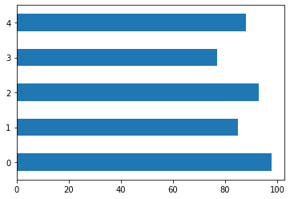

```python
# univariate
s_grades.plot.barh()
```

## DataFrame

A simple definition of DataFrame: **it's a 2-dimensional array.**

For our dataset, we used the one we download from Kaggle: https://www.kaggle.com/datasets/residentmario/ramen-ratings?select=ramen-ratings.csv

In the next cell, you will read the csv file using .read_csv()

```python
df = pd.read_csv('ramen-ratings.csv')
```

### DataFrame Familiarization!!

Let's get ourselves familiarized with some of the most widely used attributes and callable functions for DataFrame.

#### .shape: to check the number of rows and columns

```python
df.shape # since the returned value is a tuple (2580, 7), we can access it by index
```

```
(2580, 7)
```

```python
df.shape[0] # number of rows
```

```
2580
```

```python
df.shape[1] # number of columns
```

```
7
```

#### Once you open the dataframe, it will provide you the default top 5 and bottom 5 rows

```python
df
```

|  | Review # | Brand | Variety | Style | Country | Stars | Top Ten |
| --- | --- | --- | --- | --- | --- | --- | --- |
| 0 | 2580 | New Touch | T's Restaurant Tantanmen | Cup | Japan | 3.75 | NaN |
| 1 | 2579 | Just Way | Noodles Spicy Hot Sesame Spicy Hot Sesame Guan... | Pack | Taiwan | 1 | NaN |
| 2 | 2578 | Nissin | Cup Noodles Chicken Vegetable | Cup | USA | 2.25 | NaN |
| 3 | 2577 | Wei Lih | GGE Ramen Snack Tomato Flavor | Pack | Taiwan | 2.75 | NaN |
| 4 | 2576 | Ching's Secret | Singapore Curry | Pack | India | 3.75 | NaN |
| ... | ... | ... | ... | ... | ... | ... | ... |
| 2575 | 5 | Vifon | Hu Tiu Nam Vang ["Phnom Penh" style] Asian Sty... | Bowl | Vietnam | 3.5 | NaN |
| 2576 | 4 | Wai Wai | Oriental Style Instant Noodles | Pack | Thailand | 1 | NaN |
| 2577 | 3 | Wai Wai | Tom Yum Shrimp | Pack | Thailand | 2 | NaN |
| 2578 | 2 | Wai Wai | Tom Yum Chili Flavor | Pack | Thailand | 2 | NaN |
| 2579 | 1 | Westbrae | Miso Ramen | Pack | USA | 0.5 | NaN |

2580 rows × 7 columns

#### .head(): returns the top 5 rows

```python
df.head()
```

|  | Review # | Brand | Variety | Style | Country | Stars | Top Ten |
| --- | --- | --- | --- | --- | --- | --- | --- |
| 0 | 2580 | New Touch | T's Restaurant Tantanmen | Cup | Japan | 3.75 | NaN |
| 1 | 2579 | Just Way | Noodles Spicy Hot Sesame Spicy Hot Sesame Guan... | Pack | Taiwan | 1 | NaN |
| 2 | 2578 | Nissin | Cup Noodles Chicken Vegetable | Cup | USA | 2.25 | NaN |
| 3 | 2577 | Wei Lih | GGE Ramen Snack Tomato Flavor | Pack | Taiwan | 2.75 | NaN |
| 4 | 2576 | Ching's Secret | Singapore Curry | Pack | India | 3.75 | NaN |

#### .tail(): returns the bottom 5 rows

```python
df.tail()
```

|  | Review # | Brand | Variety | Style | Country | Stars | Top Ten |
| --- | --- | --- | --- | --- | --- | --- | --- |
| 2575 | 5 | Vifon | Hu Tiu Nam Vang ["Phnom Penh" style] Asian Sty... | Bowl | Vietnam | 3.5 | NaN |
| 2576 | 4 | Wai Wai | Oriental Style Instant Noodles | Pack | Thailand | 1 | NaN |
| 2577 | 3 | Wai Wai | Tom Yum Shrimp | Pack | Thailand | 2 | NaN |
| 2578 | 2 | Wai Wai | Tom Yum Chili Flavor | Pack | Thailand | 2 | NaN |
| 2579 | 1 | Westbrae | Miso Ramen | Pack | USA | 0.5 | NaN |

#### .columns: returns the list of column available in the dataframe

```python
df.columns
```

```
Index(['Review #', 'Brand', 'Variety', 'Style', 'Country', 'Stars', 'Top Ten'], dtype='object')
```

#### .dtypes: returns the data type of each column

- object = categorical/nominal values, you can think of this a string literal
- int64/float64 = numerical values or continuous

```python
df.dtypes
```

```
Review #     int64
Brand       object
Variety     object
Style       object
Country     object
Stars       object
Top Ten     object
dtype: object
```

### Further review in 'Stars' column: check what makes it 'object' dtype

#### .value_counts(): frequency count per value

```python
df['Stars'].value_counts()
```

```
4          384
5          369
3.75       350
3.5        326
3          173
3.25       170
4.25       143
4.5        132
2.75        85
2           68
2.5         67
4.75        64
1.5         37
1.75        27
0           26
1           26
2.25        21
0.5         14
0.25        11
1.25        10
5.0         10
3.50         9
5.00         7
4.00         6
4.3          4
4.0          3
Unrated      3
4.50         3
3.8          3
2.3          2
3.0          2
3.1          2
1.1          2
4.125        2
2.8          2
2.9          2
2.1          1
3.00         1
0.9          1
3.125        1
3.3          1
2.85         1
3.6          1
3.65         1
3.7          1
3.2          1
1.8          1
3.4          1
0.1          1
2.125        1
0.75         1
Name: Stars, dtype: int64
```

#### remove the 'Unrated' value and convert it to float

```python
df = df[df['Stars']!='Unrated'] # reassign the filtering to df object again
```

#### .astype(): convert the 'object' dtype into 'float' dtype

```python
df['Stars'] = df['Stars'].astype(float)
```

#### .info(): provides quick summary of the DataFrame containing the column names, its value null count and datatypes

```python
df.info()
```

```
<class 'pandas.core.frame.DataFrame'>
Int64Index: 2577 entries, 0 to 2579
Data columns (total 7 columns):
 #   Column    Non-Null Count  Dtype
---  ------    --------------  -----
 0   Review #  2577 non-null   int64
 1   Brand     2577 non-null   object
 2   Variety   2577 non-null   object
 3   Style     2575 non-null   object
 4   Country   2577 non-null   object
 5   Stars     2577 non-null   float64
 6   Top Ten   41 non-null     object
dtypes: float64(1), int64(1), object(5)
memory usage: 161.1+ KB
```

#### .isnull(): checks the value if it's null or no

#### .sum(): returns the summation of values

Take note: you can specify succeeding callable function or combination of other callable function.

See cell below, for **.isnull().sum()**:

```python
df.isnull().sum()
```

```
Review #       0
Brand          0
Variety        0
Style          2
Country        0
Stars          0
Top Ten     2536
dtype: int64
```

#### .describe(): returns DataFrame's descriptive statistics

You can specify the parameter **include** with an argument of the datatype you want to describe.

```python
# descriptive stats: categorical/nominal
df.describe(include=['object'])
```

|  | Brand | Variety | Style | Country | Top Ten |
| --- | --- | --- | --- | --- | --- |
| count | 2577 | 2577 | 2575 | 2577 | 41 |
| unique | 355 | 2410 | 7 | 38 | 38 |
| top | Nissin | Beef | Pack | Japan | \n |
| freq | 381 | 7 | 1528 | 352 | 4 |

```python
# descriptive stats: all values
df.describe(include='all')
```

|  | Review # | Brand | Variety | Style | Country | Stars | Top Ten |
| --- | --- | --- | --- | --- | --- | --- | --- |
| count | 2577.000000 | 2577 | 2577 | 2575 | 2577 | 2577.000000 | 41 |
| unique | NaN | 355 | 2410 | 7 | 38 | NaN | 38 |
| top | NaN | Nissin | Beef | Pack | Japan | NaN | \n |
| freq | NaN | 381 | 7 | 1528 | 352 | NaN | 4 |
| mean | 1289.443927 | NaN | NaN | NaN | NaN | 3.654676 | NaN |
| std | 744.569010 | NaN | NaN | NaN | NaN | 1.015331 | NaN |
| min | 1.000000 | NaN | NaN | NaN | NaN | 0.000000 | NaN |
| 25% | 645.000000 | NaN | NaN | NaN | NaN | 3.250000 | NaN |
| 50% | 1289.000000 | NaN | NaN | NaN | NaN | 3.750000 | NaN |
| 75% | 1934.000000 | NaN | NaN | NaN | NaN | 4.250000 | NaN |
| max | 2580.000000 | NaN | NaN | NaN | NaN | 5.000000 | NaN |

#### Nested callables/functions

Remember: you can call multiple callable functions right after each one. Don't forget to always do <shift+tab> on each callable function to explore arguments.

In the next cell, we will use **.plot()** at the end to demonstrate that we can perform visualization based on frequency count distribution using **.value_counts()**

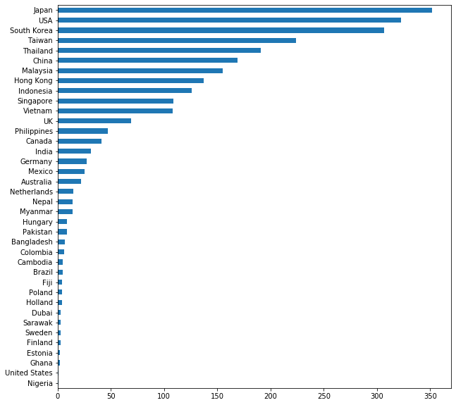

```python
df.Country.value_counts().sort_values().plot(kind='barh',figsize=[10,10])
```

#### Inplace Argument

Instead of reassigning to the same variable, most of the callables in pandas has **inplace** argument which when set to True, will update the current object based on whatever changes you performed with it.

```python
df.set_index('Review #',inplace=True) # isntead of assigning, add inplace=True as an argument
```

### Quick Insights for Column

#### .unique(): returns the distinct values under a column

```python
df['Country'].unique()
```

```
array(['Japan', 'Taiwan', 'USA', 'India', 'South Korea', 'Singapore',
       'Thailand', 'Hong Kong', 'Vietnam', 'Ghana', 'Malaysia',
       'Indonesia', 'China', 'Nigeria', 'Germany', 'Hungary', 'Mexico',
       'Fiji', 'Australia', 'Pakistan', 'Bangladesh', 'Canada', 'Nepal',
       'Brazil', 'UK', 'Myanmar', 'Netherlands', 'United States',
       'Cambodia', 'Finland', 'Sarawak', 'Philippines', 'Sweden',
       'Colombia', 'Estonia', 'Holland', 'Poland', 'Dubai'], dtype=object)
```

#### .min(): returns the lowest value in a column

```python
df['Stars'].min()
```

```
0.0
```

#### .max(): returns the highest value in a column

```python
df['Stars'].max()
```

```
5.0
```

#### performing math functions | round(): returns the rounded value of a number

```python
round(df['Stars'].mean(),2)
```

```
3.65
```

### DataFrame Slicing

#### Column Selection

Remember, you can select multiple columns and put it as a list either directly in the DataFrame or storing it in a variable

```python
df[['Variety','Country','Stars']] # directly in a DataFrame
```

| Review # | Variety | Country | Stars |
| --- | --- | --- | --- |
| 2580 | T's Restaurant Tantanmen | Japan | 3.75 |
| 2579 | Noodles Spicy Hot Sesame Spicy Hot Sesame Guan... | Taiwan | 1.00 |
| 2578 | Cup Noodles Chicken Vegetable | USA | 2.25 |
| 2577 | GGE Ramen Snack Tomato Flavor | Taiwan | 2.75 |
| 2576 | Singapore Curry | India | 3.75 |
| ... | ... | ... | ... |
| 5 | Hu Tiu Nam Vang ["Phnom Penh" style] Asian Sty... | Vietnam | 3.50 |
| 4 | Oriental Style Instant Noodles | Thailand | 1.00 |
| 3 | Tom Yum Shrimp | Thailand | 2.00 |
| 2 | Tom Yum Chili Flavor | Thailand | 2.00 |
| 1 | Miso Ramen | USA | 0.50 |

2577 rows × 3 columns

```python
selected_columns = ['Variety','Country','Stars'] # storing it in a variable separately
df[selected_columns]
```

| Review # | Variety | Country | Stars |
| --- | --- | --- | --- |
| 2580 | T's Restaurant Tantanmen | Japan | 3.75 |
| 2579 | Noodles Spicy Hot Sesame Spicy Hot Sesame Guan... | Taiwan | 1.00 |
| 2578 | Cup Noodles Chicken Vegetable | USA | 2.25 |
| 2577 | GGE Ramen Snack Tomato Flavor | Taiwan | 2.75 |
| 2576 | Singapore Curry | India | 3.75 |
| ... | ... | ... | ... |
| 5 | Hu Tiu Nam Vang ["Phnom Penh" style] Asian Sty... | Vietnam | 3.50 |
| 4 | Oriental Style Instant Noodles | Thailand | 1.00 |
| 3 | Tom Yum Shrimp | Thailand | 2.00 |
| 2 | Tom Yum Chili Flavor | Thailand | 2.00 |
| 1 | Miso Ramen | USA | 0.50 |

2577 rows × 3 columns

```python
df[selected_columns].head() # performing a callable .head() after the column selection
```

| Review # | Variety | Country | Stars |
| --- | --- | --- | --- |
| 2580 | T's Restaurant Tantanmen | Japan | 3.75 |
| 2579 | Noodles Spicy Hot Sesame Spicy Hot Sesame Guan... | Taiwan | 1.00 |
| 2578 | Cup Noodles Chicken Vegetable | USA | 2.25 |
| 2577 | GGE Ramen Snack Tomato Flavor | Taiwan | 2.75 |
| 2576 | Singapore Curry | India | 3.75 |

Using the Review #, you can perform row selection. Further, you can also select column/s.

The cell below utilizes the **.loc** attribute which means you can specify your slicing based on index and column names.

```python
df.loc[2580:2578] # Review# index
```

| Review # | Brand | Variety | Style | Country | Stars | Top Ten |
| --- | --- | --- | --- | --- | --- | --- |
| 2580 | New Touch | T's Restaurant Tantanmen | Cup | Japan | 3.75 | NaN |
| 2579 | Just Way | Noodles Spicy Hot Sesame Spicy Hot Sesame Guan... | Pack | Taiwan | 1.00 | NaN |
| 2578 | Nissin | Cup Noodles Chicken Vegetable | Cup | USA | 2.25 | NaN |

```python
df.loc[2580:2578, ['Country','Stars']] # Review# index and list of columns
```

| Review # | Country | Stars |
| --- | --- | --- |
| 2580 | Japan | 3.75 |
| 2579 | Taiwan | 1.00 |
| 2578 | USA | 2.25 |

### Filtering based on conditions

```python
# filter: where value of Stars > 3.0
df[df['Stars']>3.0]
```

| Review # | Brand | Variety | Style | Country | Stars | Top Ten |
| --- | --- | --- | --- | --- | --- | --- |
| 2580 | New Touch | T's Restaurant Tantanmen | Cup | Japan | 3.75 | NaN |
| 2576 | Ching's Secret | Singapore Curry | Pack | India | 3.75 | NaN |
| 2575 | Samyang Foods | Kimchi song Song Ramen | Pack | South Korea | 4.75 | NaN |
| 2574 | Acecook | Spice Deli Tantan Men With Cilantro | Cup | Japan | 4.00 | NaN |
| 2573 | Ikeda Shoku | Nabeyaki Kitsune Udon | Tray | Japan | 3.75 | NaN |
| ... | ... | ... | ... | ... | ... | ... |
| 18 | Ottogi | Jin Ramen (Hot Taste) | Pack | South Korea | 3.50 | NaN |
| 16 | Samyang | Kalgug-Su (Spicy) | Pack | South Korea | 3.50 | NaN |
| 14 | Samyang | Hot | Pack | South Korea | 3.50 | NaN |
| 13 | Sapporo Ichiban | Chow Mein | Pack | Japan | 5.00 | 2012 #4 |
| 5 | Vifon | Hu Tiu Nam Vang ["Phnom Penh" style] Asian Sty... | Bowl | Vietnam | 3.50 | NaN |

1994 rows × 6 columns

```python
# filter using 2 conditions: where value of Stars > 3.0 and Country is Philippines
df[(df['Stars']>3.0) & (df['Country']=='Philippines')]
```

| Review # | Brand | Variety | Style | Country | Stars | Top Ten |
| --- | --- | --- | --- | --- | --- | --- |
| 1645 | Lucky Me! | Supreme Jjamppong Korean Style Spicy Seafood Soup | Bowl | Philippines | 3.75 | NaN |
| 1611 | Lucky Me! | Supreme Seafood Flavor Big Cup | Bowl | Philippines | 4.00 | NaN |
| 1532 | Lucky Me! | Special Instant Noodles Jjamppong Flavor | Pack | Philippines | 4.50 | NaN |
| 1531 | Lucky Me! | Special Instant sopas Chicken Flavor | Pack | Philippines | 3.75 | NaN |
| 1530 | Lucky Me! | Spicy Beef Mami Instant Noodle Soup | Pack | Philippines | 4.00 | NaN |
| 1529 | Lucky Me! | Special Instant Curly Spaghetti With Yummy Red... | Pack | Philippines | 4.00 | NaN |
| 1528 | Lucky Me! | Supreme Pinoy Chicken Instant Noodles | Cup | Philippines | 3.25 | NaN |
| 1527 | Lucky Me! | Special Baked Mac Style Instant Macaroni | Pack | Philippines | 4.50 | NaN |
| 1526 | Lucky Me! | La Paz Batchoy Instant Noodle Soup | Pack | Philippines | 3.75 | NaN |
| 1408 | Pamana | Chicken Sopas Creamy Macaroni Soup | Cup | Philippines | 3.50 | NaN |
| 1285 | Lucky Me! | Supreme Chow Mein Seafood Flavor Instant Stir-... | Bowl | Philippines | 3.25 | NaN |
| 1128 | Lucky Me! | Special Instant Pancit Bihon With Kalamansi | Pack | Philippines | 3.25 | NaN |
| 744 | Payless | Instant Mami Beef | Pack | Philippines | 3.25 | NaN |
| 660 | Lucky Me! | Beef Na Beef | Pack | Philippines | 3.75 | NaN |
| 628 | Lucky Me! | Supreme La Paz Batchoy Beef Garlic | Bowl | Philippines | 3.50 | NaN |
| 599 | Lucky Me! | Pancit Canton Extra Hot Chili | Pack | Philippines | 4.00 | NaN |
| 547 | Lucky Me! | Pancit Canton Sweet Spicy | Pack | Philippines | 5.00 | NaN |
| 443 | Lucky Me! | N-Rich Chicken Tinola | Pack | Philippines | 4.00 | NaN |
| 433 | Lucky Me! | Supreme Bulalo | Bowl | Philippines | 3.25 | NaN |
| 430 | Quickchow | Pancit Canton toyo Mansi | Pack | Philippines | 5.00 | NaN |
| 429 | Quickchow | Chicken Mami | Pack | Philippines | 3.75 | NaN |
| 410 | Lucky Me! | Instant Bulalo Bone Marrow | Pack | Philippines | 3.75 | NaN |
| 409 | Payless | Instant Mami Chicken | Pack | Philippines | 4.00 | NaN |
| 357 | Payless | Xtra Big Kalamansi Pancit Canton | Pack | Philippines | 4.00 | NaN |
| 339 | Payless | Xtra Big Chilimansi Pancit Canton | Pack | Philippines | 4.50 | NaN |
| 305 | Lucky Me! | Supreme Special Beef Carne De Vaca | Bowl | Philippines | 3.75 | NaN |
| 299 | Lucky Me! | Supreme Sotanghon Artificial Chicken Vermicelli | Bowl | Philippines | 3.75 | NaN |
| 230 | Lucky Me! | Supreme Instant Mami Noodles With Free Crackers | Bowl | Philippines | 3.75 | NaN |
| 155 | Lucky Me! | Pancit Canton | Pack | Philippines | 4.75 | NaN |
| 93 | Payless | Xtra Big Original Pancit Canton | Pack | Philippines | 4.50 | NaN |

```python
# filter: search for keyword using .contains() - i.e., locating 'Canton'
df[df['Variety'].str.contains('Canton')]
```

| Review # | Brand | Variety | Style | Country | Stars | Top Ten |
| --- | --- | --- | --- | --- | --- | --- |
| 599 | Lucky Me! | Pancit Canton Extra Hot Chili | Pack | Philippines | 4.00 | NaN |
| 547 | Lucky Me! | Pancit Canton Sweet Spicy | Pack | Philippines | 5.00 | NaN |
| 430 | Quickchow | Pancit Canton toyo Mansi | Pack | Philippines | 5.00 | NaN |
| 357 | Payless | Xtra Big Kalamansi Pancit Canton | Pack | Philippines | 4.00 | NaN |
| 339 | Payless | Xtra Big Chilimansi Pancit Canton | Pack | Philippines | 4.50 | NaN |
| 155 | Lucky Me! | Pancit Canton | Pack | Philippines | 4.75 | NaN |
| 93 | Payless | Xtra Big Original Pancit Canton | Pack | Philippines | 4.50 | NaN |
| 40 | Lucky Me! | Pancit Canton Chili Mansi | Pack | Philippines | 3.00 | NaN |
| 38 | Lucky Me! | Pancit Canton Citrus Flavor | Pack | Philippines | 3.00 | NaN |
| 37 | Lucky Me! | Pancit Canton Hot Chili Flavor | Pack | Philippines | 3.00 | NaN |

```python
# filter: search for specific value using '==' comparison operator
df[df['Country']=='Philippines']
```

| Review # | Brand | Variety | Style | Country | Stars | Top Ten |
| --- | --- | --- | --- | --- | --- | --- |
| 1645 | Lucky Me! | Supreme Jjamppong Korean Style Spicy Seafood Soup | Bowl | Philippines | 3.75 | NaN |
| 1611 | Lucky Me! | Supreme Seafood Flavor Big Cup | Bowl | Philippines | 4.00 | NaN |
| 1532 | Lucky Me! | Special Instant Noodles Jjamppong Flavor | Pack | Philippines | 4.50 | NaN |
| 1531 | Lucky Me! | Special Instant sopas Chicken Flavor | Pack | Philippines | 3.75 | NaN |
| 1530 | Lucky Me! | Spicy Beef Mami Instant Noodle Soup | Pack | Philippines | 4.00 | NaN |
| 1529 | Lucky Me! | Special Instant Curly Spaghetti With Yummy Red... | Pack | Philippines | 4.00 | NaN |
| 1528 | Lucky Me! | Supreme Pinoy Chicken Instant Noodles | Cup | Philippines | 3.25 | NaN |
| 1527 | Lucky Me! | Special Baked Mac Style Instant Macaroni | Pack | Philippines | 4.50 | NaN |
| 1526 | Lucky Me! | La Paz Batchoy Instant Noodle Soup | Pack | Philippines | 3.75 | NaN |
| 1408 | Pamana | Chicken Sopas Creamy Macaroni Soup | Cup | Philippines | 3.50 | NaN |
| 1285 | Lucky Me! | Supreme Chow Mein Seafood Flavor Instant Stir-... | Bowl | Philippines | 3.25 | NaN |
| 1128 | Lucky Me! | Special Instant Pancit Bihon With Kalamansi | Pack | Philippines | 3.25 | NaN |
| 744 | Payless | Instant Mami Beef | Pack | Philippines | 3.25 | NaN |
| 660 | Lucky Me! | Beef Na Beef | Pack | Philippines | 3.75 | NaN |
| 628 | Lucky Me! | Supreme La Paz Batchoy Beef Garlic | Bowl | Philippines | 3.50 | NaN |
| 599 | Lucky Me! | Pancit Canton Extra Hot Chili | Pack | Philippines | 4.00 | NaN |
| 547 | Lucky Me! | Pancit Canton Sweet Spicy | Pack | Philippines | 5.00 | NaN |
| 538 | Lucky Me! | Lomi Seafood Vegetable | Pack | Philippines | 0.50 | NaN |
| 443 | Lucky Me! | N-Rich Chicken Tinola | Pack | Philippines | 4.00 | NaN |
| 433 | Lucky Me! | Supreme Bulalo | Bowl | Philippines | 3.25 | NaN |
| 430 | Quickchow | Pancit Canton toyo Mansi | Pack | Philippines | 5.00 | NaN |
| 429 | Quickchow | Chicken Mami | Pack | Philippines | 3.75 | NaN |
| 410 | Lucky Me! | Instant Bulalo Bone Marrow | Pack | Philippines | 3.75 | NaN |
| 409 | Payless | Instant Mami Chicken | Pack | Philippines | 4.00 | NaN |
| 397 | Quickchow | Quickie Mami La Paz Batchoy | Cup | Philippines | 3.00 | NaN |
| 383 | Lucky Me! | Chicken Na Chicken | Pack | Philippines | 2.75 | NaN |
| 382 | Lucky Me! | N-Rich Artificial Chicken With Ginger | Pack | Philippines | 2.50 | NaN |
| 366 | Payless | Pancit Shanghai | Pack | Philippines | 2.75 | NaN |
| 357 | Payless | Xtra Big Kalamansi Pancit Canton | Pack | Philippines | 4.00 | NaN |
| 339 | Payless | Xtra Big Chilimansi Pancit Canton | Pack | Philippines | 4.50 | NaN |
| 312 | Lucky Me! | Supreme Bulalo Artificial Bone Marrow | Bowl | Philippines | 1.75 | NaN |
| 310 | Lucky Me! | La Paz Batchoy Beef | Pack | Philippines | 2.50 | NaN |
| 305 | Lucky Me! | Supreme Special Beef Carne De Vaca | Bowl | Philippines | 3.75 | NaN |
| 299 | Lucky Me! | Supreme Sotanghon Artificial Chicken Vermicelli | Bowl | Philippines | 3.75 | NaN |
| 230 | Lucky Me! | Supreme Instant Mami Noodles With Free Crackers | Bowl | Philippines | 3.75 | NaN |
| 227 | Quickchow | Bihon Guisado Rice Noodle | Pack | Philippines | 1.75 | NaN |
| 174 | Lucky Me! | Sotanghon Artificial Chicken | Pack | Philippines | 0.25 | NaN |
| 157 | Nissin | Sotanghon | Cup | Philippines | 2.00 | NaN |
| 155 | Lucky Me! | Pancit Canton | Pack | Philippines | 4.75 | NaN |
| 110 | Lucky Me! | Artificial Chicken | Pack | Philippines | 1.50 | NaN |
| 93 | Payless | Xtra Big Original Pancit Canton | Pack | Philippines | 4.50 | NaN |
| 40 | Lucky Me! | Pancit Canton Chili Mansi | Pack | Philippines | 3.00 | NaN |
| 39 | Lucky Me! | Supreme Bulalo Flavor | Bowl | Philippines | 3.00 | NaN |
| 38 | Lucky Me! | Pancit Canton Citrus Flavor | Pack | Philippines | 3.00 | NaN |
| 37 | Lucky Me! | Pancit Canton Hot Chili Flavor | Pack | Philippines | 3.00 | NaN |
| 36 | Lucky Me! | Itnok | Pack | Philippines | 3.00 | NaN |
| 17 | Quickchow | Pancit Palabok | Pack | Philippines | 2.50 | NaN |

### DataFrame: Column/Row Drop

#### Removing of rows

Remember, you can reassign DataFrame in a variable or utilize **inplace** argument

```python
df_removed = df.drop(2580) # using index to remove a particular row; then, reassign it
df_removed
```

| Review # | Brand | Variety | Style | Country | Stars | Top Ten |
| --- | --- | --- | --- | --- | --- | --- |
| 2579 | Just Way | Noodles Spicy Hot Sesame Spicy Hot Sesame Guan... | Pack | Taiwan | 1.00 | NaN |
| 2578 | Nissin | Cup Noodles Chicken Vegetable | Cup | USA | 2.25 | NaN |
| 2577 | Wei Lih | GGE Ramen Snack Tomato Flavor | Pack | Taiwan | 2.75 | NaN |
| 2576 | Ching's Secret | Singapore Curry | Pack | India | 3.75 | NaN |
| 2575 | Samyang Foods | Kimchi song Song Ramen | Pack | South Korea | 4.75 | NaN |
| ... | ... | ... | ... | ... | ... | ... |
| 5 | Vifon | Hu Tiu Nam Vang ["Phnom Penh" style] Asian Sty... | Bowl | Vietnam | 3.50 | NaN |
| 4 | Wai Wai | Oriental Style Instant Noodles | Pack | Thailand | 1.00 | NaN |
| 3 | Wai Wai | Tom Yum Shrimp | Pack | Thailand | 2.00 | NaN |
| 2 | Wai Wai | Tom Yum Chili Flavor | Pack | Thailand | 2.00 | NaN |
| 1 | Westbrae | Miso Ramen | Pack | USA | 0.50 | NaN |

2576 rows × 6 columns

```python
df.drop(2580,inplace=True) # using index to remove a particular row; then, utilizes inplace argument to true
df
```

| Review # | Brand | Variety | Style | Country | Stars | Top Ten |
| --- | --- | --- | --- | --- | --- | --- |
| 2579 | Just Way | Noodles Spicy Hot Sesame Spicy Hot Sesame Guan... | Pack | Taiwan | 1.00 | NaN |
| 2578 | Nissin | Cup Noodles Chicken Vegetable | Cup | USA | 2.25 | NaN |
| 2577 | Wei Lih | GGE Ramen Snack Tomato Flavor | Pack | Taiwan | 2.75 | NaN |
| 2576 | Ching's Secret | Singapore Curry | Pack | India | 3.75 | NaN |
| 2575 | Samyang Foods | Kimchi song Song Ramen | Pack | South Korea | 4.75 | NaN |
| ... | ... | ... | ... | ... | ... | ... |
| 5 | Vifon | Hu Tiu Nam Vang ["Phnom Penh" style] Asian Sty... | Bowl | Vietnam | 3.50 | NaN |
| 4 | Wai Wai | Oriental Style Instant Noodles | Pack | Thailand | 1.00 | NaN |
| 3 | Wai Wai | Tom Yum Shrimp | Pack | Thailand | 2.00 | NaN |
| 2 | Wai Wai | Tom Yum Chili Flavor | Pack | Thailand | 2.00 | NaN |
| 1 | Westbrae | Miso Ramen | Pack | USA | 0.50 | NaN |

2576 rows × 6 columns

#### Removing of columns

**axis=1** means that you are referring to the vertical position in a DataFrame; hence, the column

```python
df.drop(columns='Top Ten',axis=1,inplace=True)
df
```

| Review # | Brand | Variety | Style | Country | Stars |
| --- | --- | --- | --- | --- | --- |
| 2579 | Just Way | Noodles Spicy Hot Sesame Spicy Hot Sesame Guan... | Pack | Taiwan | 1.00 |
| 2578 | Nissin | Cup Noodles Chicken Vegetable | Cup | USA | 2.25 |
| 2577 | Wei Lih | GGE Ramen Snack Tomato Flavor | Pack | Taiwan | 2.75 |
| 2576 | Ching's Secret | Singapore Curry | Pack | India | 3.75 |
| 2575 | Samyang Foods | Kimchi song Song Ramen | Pack | South Korea | 4.75 |
| ... | ... | ... | ... | ... | ... |
| 5 | Vifon | Hu Tiu Nam Vang ["Phnom Penh" style] Asian Sty... | Bowl | Vietnam | 3.50 |
| 4 | Wai Wai | Oriental Style Instant Noodles | Pack | Thailand | 1.00 |
| 3 | Wai Wai | Tom Yum Shrimp | Pack | Thailand | 2.00 |
| 2 | Wai Wai | Tom Yum Chili Flavor | Pack | Thailand | 2.00 |
| 1 | Westbrae | Miso Ramen | Pack | USA | 0.50 |

2576 rows × 5 columns

### DataFrame Groupby Function

You can perform groupby() callable to gain insights about categorical values.

Remember, you can perform multiple callable function right after each other.

```python
# grouped by County; selected Stars to get the average ratings per country
df.groupby('Country')[['Stars']].mean().sort_values(by='Stars')
```

| Country | Stars |
| --- | --- |
| Nigeria | 1.500000 |
| Canada | 2.243902 |
| Netherlands | 2.483333 |
| UK | 2.997101 |
| Pakistan | 3.000000 |
| Australia | 3.138636 |
| Vietnam | 3.187963 |
| Sweden | 3.250000 |
| Colombia | 3.291667 |
| Philippines | 3.329787 |
| Thailand | 3.384817 |
| India | 3.395161 |
| China | 3.421893 |
| USA | 3.457043 |
| Estonia | 3.500000 |
| Ghana | 3.500000 |
| Nepal | 3.553571 |
| Holland | 3.562500 |
| Dubai | 3.583333 |
| Finland | 3.583333 |
| Hungary | 3.611111 |
| Poland | 3.625000 |
| Germany | 3.638889 |
| Taiwan | 3.665402 |
| Bangladesh | 3.714286 |
| Mexico | 3.730000 |
| United States | 3.750000 |
| South Korea | 3.790554 |
| Hong Kong | 3.801825 |
| Fiji | 3.875000 |
| Myanmar | 3.946429 |
| Japan | 3.982265 |
| Indonesia | 4.067460 |
| Singapore | 4.126147 |
| Malaysia | 4.154194 |
| Cambodia | 4.200000 |
| Sarawak | 4.333333 |
| Brazil | 4.350000 |

```python
# grouped by County; selected Stars to get the number of ratings per country
df.groupby('Country')[['Stars']].count().sort_values(by='Stars')
```

| Country | Stars |
| --- | --- |
| Nigeria | 1 |
| United States | 1 |
| Ghana | 2 |
| Estonia | 2 |
| Sarawak | 3 |
| Sweden | 3 |
| Finland | 3 |
| Dubai | 3 |
| Holland | 4 |
| Fiji | 4 |
| Poland | 4 |
| Cambodia | 5 |
| Brazil | 5 |
| Colombia | 6 |
| Bangladesh | 7 |
| Pakistan | 9 |
| Hungary | 9 |
| Nepal | 14 |
| Myanmar | 14 |
| Netherlands | 15 |
| Australia | 22 |
| Mexico | 25 |
| Germany | 27 |
| India | 31 |
| Canada | 41 |
| Philippines | 47 |
| UK | 69 |
| Vietnam | 108 |
| Singapore | 109 |
| Indonesia | 126 |
| Hong Kong | 137 |
| Malaysia | 155 |
| China | 169 |
| Thailand | 191 |
| Taiwan | 224 |
| South Korea | 307 |
| USA | 323 |
| Japan | 351 |

```python
# grouped by Brand; selected Stars to get the average ratings per Brand
df.groupby('Brand')[['Stars']].mean().sort_values(by='Stars')
```

| Brand | Stars |
| --- | --- |
| Hsin Tung Yang | 0.0 |
| Kim Ve Wong | 0.0 |
| Roland | 0.0 |
| Tiger | 0.0 |
| US Canning | 0.0 |
| ... | ... |
| Torishi | 5.0 |
| Jackpot Teriyaki | 5.0 |
| Takamori | 5.0 |
| Prima | 5.0 |
| Foodmon | 5.0 |

355 rows × 1 columns

```python
# grouped by Brand; selected Stars to get the descriptive statistics of ratings per Brand
df.groupby('Brand')[['Stars']].describe()
```

| Brand | Stars count | Stars mean | Stars std | Stars min | Stars 25% | Stars 50% | Stars 75% | Stars max |
| --- | --- | --- | --- | --- | --- | --- | --- | --- |
| 1 To 3 Noodles | 1.0 | 4.000000 | NaN | 4.00 | 4.0000 | 4.000 | 4.0000 | 4.00 |
| 7 Select | 2.0 | 3.750000 | 0.353553 | 3.50 | 3.6250 | 3.750 | 3.8750 | 4.00 |
| 7 Select/Nissin | 1.0 | 3.500000 | NaN | 3.50 | 3.5000 | 3.500 | 3.5000 | 3.50 |
| A-One | 4.0 | 2.750000 | 1.020621 | 1.25 | 2.5625 | 3.125 | 3.3125 | 3.50 |
| A-Sha Dry Noodle | 26.0 | 4.067308 | 0.723041 | 2.00 | 3.7500 | 4.000 | 4.4375 | 5.00 |
| ... | ... | ... | ... | ... | ... | ... | ... | ... |
| Yum Yum | 12.0 | 3.750000 | 0.639602 | 3.00 | 3.4375 | 3.500 | 3.8125 | 5.00 |
| Yum-Mie | 1.0 | 3.500000 | NaN | 3.50 | 3.5000 | 3.500 | 3.5000 | 3.50 |
| Zow Zow | 1.0 | 3.750000 | NaN | 3.75 | 3.7500 | 3.750 | 3.7500 | 3.75 |
| iMee | 4.0 | 3.500000 | 0.735980 | 2.75 | 3.1250 | 3.375 | 3.7500 | 4.50 |
| iNoodle | 2.0 | 3.000000 | 1.060660 | 2.25 | 2.6250 | 3.000 | 3.3750 | 3.75 |

355 rows × 8 columns